# UCC Data & Analytics Society: Exploring DotA2 Match Data

All code and data for this workshop is available at the following URL:

https://github.com/kaybenleroll/data_workshops

Code is available in the `ws_ucc_intro_202111/` directory.

# 1 Load Data

```r
matchdata_tbl <- read_rds("data/matchdata_wide_tbl.rds")
matchdata_tbl %>% glimpse()
```

```
## Rows: 92,650
## Columns: 117
## $ result    <int> -1, 1, 1, 1, -1, 1, 1, -1, -1, -1, 1, -1, -1, -1, -1, -1, 1,…
## $ cluster   <chr> "223", "152", "131", "154", "171", "122", "224", "227", "111…
## $ game_mode <chr> "2", "2", "2", "2", "2", "2", "8", "8", "2", "2", "2", "2", …
## $ game_type <chr> "2", "2", "2", "2", "3", "3", "3", "3", "3", "2", "3", "2", …
## $ `1`       <int> 0, 0, 0, 0, 0, 0, 0, 0, 0, 0, 0, -1, 0, 0, 0, 0, 0, 0, 0, 1,…
## $ `2`       <int> 0, 0, 0, 0, 0, 1, 0, -1, 0, 0, 1, 0, 0, 1, 0, 0, 0, 0, 0, 0,…
## $ `3`       <int> 0, 0, 0, 0, 0, 0, 0, 0, 1, 0, 0, 1, 0, 0, 0, 0, 0, 0, 0, 0, …
## $ `4`       <int> 0, 1, 1, 0, 0, 0, 0, 0, 0, 1, 0, 0, 0, 0, 1, -1, 0, 0, 1, -1…
## $ `5`       <int> 0, 0, 0, 0, 0, 0, 0, 0, 0, 0, 1, 0, 0, -1, 0, 0, 0, 0, 0, 0,…
## $ `6`       <int> 0, -1, -1, 0, -1, 0, 0, 0, 0, 0, 1, 0, 0, -1, 0, 1, 0, -1, 0…
## $ `7`       <int> 0, 0, 0, -1, 0, 0, 0, 0, 0, 0, 0, 0, 0, 0, 0, 0, 0, 0, 0, 0,…
## $ `8`       <int> 0, 0, 0, 0, 0, 0, 0, 0, -1, -1, -1, 0, 0, 0, 0, 0, 0, 0, 1, …
## $ `9`       <int> 0, 0, 0, 0, -1, 0, 0, 0, 0, 0, 0, 1, 0, 0, 0, 0, 0, -1, 0, 1…
```

[output cut: 104 more lines]

```r
match_teamdata_tbl <- read_rds("data/match_teamdata_tbl.rds")
match_teamdata_tbl %>% glimpse()
```

```
## Rows: 926,500
## Columns: 7
## $ match_id  <chr> "MATCH000001", "MATCH000001", "MATCH000001", "MATCH000001", …
## $ result    <int> -1, -1, -1, -1, -1, -1, -1, -1, -1, -1, 1, 1, 1, 1, 1, 1, 1,…
## $ cluster   <chr> "223", "223", "223", "223", "223", "223", "223", "223", "223…
## $ game_mode <chr> "2", "2", "2", "2", "2", "2", "2", "2", "2", "2", "2", "2", …
## $ game_type <chr> "2", "2", "2", "2", "2", "2", "2", "2", "2", "2", "2", "2", …
## $ hero_id   <chr> "10", "14", "18", "22", "25", "28", "32", "38", "74", "88", …
## $ team_comp <int> 1, 1, -1, -1, 1, 1, 1, -1, -1, -1, 1, -1, 1, -1, 1, 1, -1, 1…
```

```r
hero_data_tbl <- read_rds("data/hero_data_tbl.rds")
hero_data_tbl %>% glimpse()
```

```
## Rows: 112
## Columns: 3
## $ hero_id        <chr> "1", "2", "3", "4", "5", "6", "7", "8", "9", "11", "10"…
## $ name           <chr> "antimage", "axe", "bane", "bloodseeker", "crystal_maid…
## $ localized_name <chr> "Anti-Mage", "Axe", "Bane", "Bloodseeker", "Crystal Mai…
```

```r
cluster_region_tbl <- read_rds("data/cluster_region_tbl.rds")
cluster_region_tbl %>% glimpse()
```

```
## Rows: 53
## Columns: 2
## $ cluster <chr> "111", "112", "113", "121", "122", "123", "124", "131", "132",…
## $ region  <chr> "US WEST", "US WEST", "US WEST", "US EAST", "US EAST", "US EAS…
```

## 1.1 Construct Fields

We want to construct additional fields.

```r
matchdata_tbl <- matchdata_tbl %>%
  left_join(cluster_region_tbl, by = "cluster")

matchdata_tbl %>% glimpse()
```

```
## Rows: 92,650
## Columns: 118
## $ result    <int> -1, 1, 1, 1, -1, 1, 1, -1, -1, -1, 1, -1, -1, -1, -1, -1, 1,…
## $ cluster   <chr> "223", "152", "131", "154", "171", "122", "224", "227", "111…
## $ game_mode <chr> "2", "2", "2", "2", "2", "2", "8", "8", "2", "2", "2", "2", …
## $ game_type <chr> "2", "2", "2", "2", "3", "3", "3", "3", "3", "2", "3", "2", …
## $ `1`       <int> 0, 0, 0, 0, 0, 0, 0, 0, 0, 0, 0, -1, 0, 0, 0, 0, 0, 0, 0, 1,…
## $ `2`       <int> 0, 0, 0, 0, 0, 1, 0, -1, 0, 0, 1, 0, 0, 1, 0, 0, 0, 0, 0, 0,…
## $ `3`       <int> 0, 0, 0, 0, 0, 0, 0, 0, 1, 0, 0, 1, 0, 0, 0, 0, 0, 0, 0, 0, …
## $ `4`       <int> 0, 1, 1, 0, 0, 0, 0, 0, 0, 1, 0, 0, 0, 0, 1, -1, 0, 0, 1, -1…
## $ `5`       <int> 0, 0, 0, 0, 0, 0, 0, 0, 0, 0, 1, 0, 0, -1, 0, 0, 0, 0, 0, 0,…
## $ `6`       <int> 0, -1, -1, 0, -1, 0, 0, 0, 0, 0, 1, 0, 0, -1, 0, 1, 0, -1, 0…
## $ `7`       <int> 0, 0, 0, -1, 0, 0, 0, 0, 0, 0, 0, 0, 0, 0, 0, 0, 0, 0, 0, 0,…
## $ `8`       <int> 0, 0, 0, 0, 0, 0, 0, 0, -1, -1, -1, 0, 0, 0, 0, 0, 0, 0, 1, …
## $ `9`       <int> 0, 0, 0, 0, -1, 0, 0, 0, 0, 0, 0, 1, 0, 0, 0, 0, 0, -1, 0, 1…
```

[output cut: 105 more lines]

```r
match_teamdata_tbl <- match_teamdata_tbl %>%
  mutate(
    team_status = if_else(result * team_comp < 0, "LOSING TEAM", "WINNING TEAM")
    ) %>%
  left_join(hero_data_tbl, by = "hero_id") %>%
  left_join(cluster_region_tbl, by = "cluster")

match_teamdata_tbl %>% glimpse()
```

```
## Rows: 926,500
## Columns: 11
## $ match_id       <chr> "MATCH000001", "MATCH000001", "MATCH000001", "MATCH0000…
## $ result         <int> -1, -1, -1, -1, -1, -1, -1, -1, -1, -1, 1, 1, 1, 1, 1, …
## $ cluster        <chr> "223", "223", "223", "223", "223", "223", "223", "223",…
## $ game_mode      <chr> "2", "2", "2", "2", "2", "2", "2", "2", "2", "2", "2", …
## $ game_type      <chr> "2", "2", "2", "2", "2", "2", "2", "2", "2", "2", "2", …
## $ hero_id        <chr> "10", "14", "18", "22", "25", "28", "32", "38", "74", "…
## $ team_comp      <int> 1, 1, -1, -1, 1, 1, 1, -1, -1, -1, 1, -1, 1, -1, 1, 1, …
## $ team_status    <chr> "LOSING TEAM", "LOSING TEAM", "WINNING TEAM", "WINNING …
## $ name           <chr> "morphling", "pudge", "sven", "zuus", "lina", "slardar"…
## $ localized_name <chr> "Morphling", "Pudge", "Sven", "Zeus", "Lina", "Slardar"…
## $ region         <chr> "PW TELECOM ZHEJIANG", "PW TELECOM ZHEJIANG", "PW TELEC…
```

Just to confirm this data has merged properly, we want to check if any of the joined tables are blank.

```r
matchdata_tbl %>%
  filter(are_na(region)) %>%
  glimpse()
```

```
## Rows: 0
## Columns: 118
## $ result    <int>
## $ cluster   <chr>
## $ game_mode <chr>
## $ game_type <chr>
## $ `1`       <int>
## $ `2`       <int>
## $ `3`       <int>
## $ `4`       <int>
## $ `5`       <int>
## $ `6`       <int>
## $ `7`       <int>
## $ `8`       <int>
## $ `9`       <int>
```

[output cut: 105 more lines]

```r
match_teamdata_tbl %>%
  filter(are_na(region)) %>%
  glimpse()
```

```
## Rows: 0
## Columns: 11
## $ match_id       <chr>
## $ result         <int>
## $ cluster        <chr>
## $ game_mode      <chr>
## $ game_type      <chr>
## $ hero_id        <chr>
## $ team_comp      <int>
## $ team_status    <chr>
## $ name           <chr>
## $ localized_name <chr>
## $ region         <chr>
```

# 2 Produce Basic Categorical Barplots

First we want to look at how some of the various categorical variables are distributed, and illustrate this by producing barplots of the counts.

We start with the region of the match.

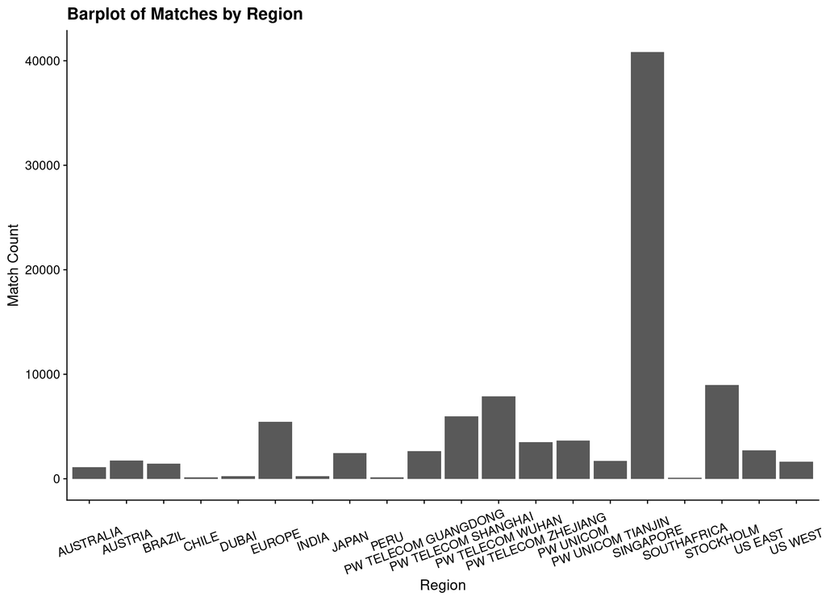

```r
plotdata_tbl <- matchdata_tbl %>%
  count(region, name = "match_count")

ggplot(plotdata_tbl) +
  geom_col(aes(x = region, y = match_count)) +
  labs(
    x = "Region",
    y = "Match Count"
    ) +
#  scale_y_log10(labels = label_comma()) +
  ggtitle("Barplot of Matches by Region") +
  theme(axis.text.x = element_text(angle = 20, vjust = 0.5))
```

Now we look at the `game_type`:

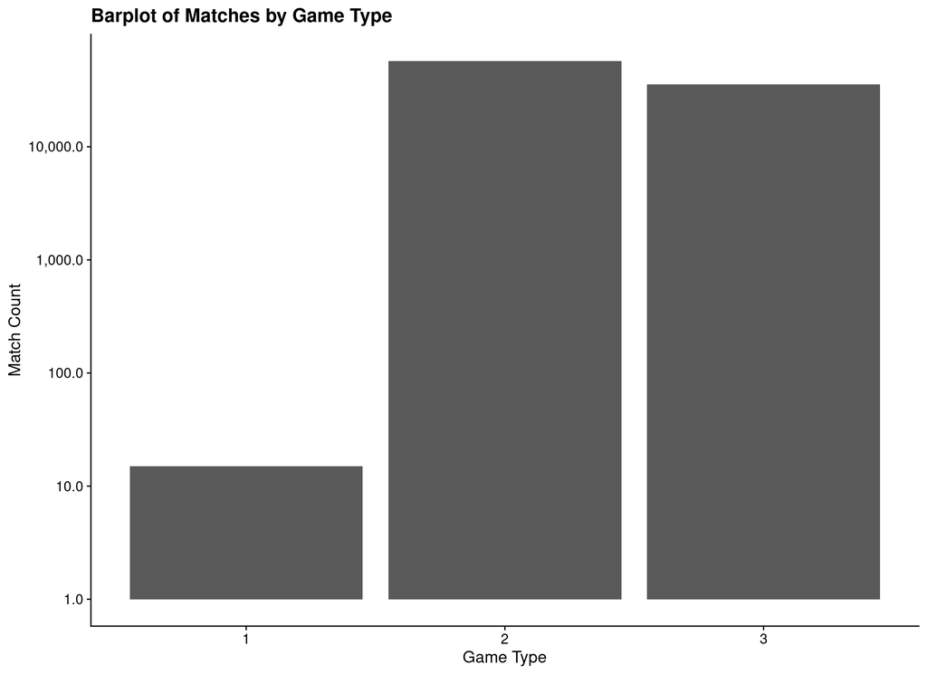

```r
plotdata_tbl <- matchdata_tbl %>%
  count(game_type, name = "match_count")

ggplot(plotdata_tbl) +
  geom_col(aes(x = game_type, y = match_count)) +
  labs(
    x = "Game Type",
    y = "Match Count"
    ) +
  scale_y_log10(labels = label_comma()) +
  ggtitle("Barplot of Matches by Game Type")
```

Finally, we look at the distribution of `game_mode`.

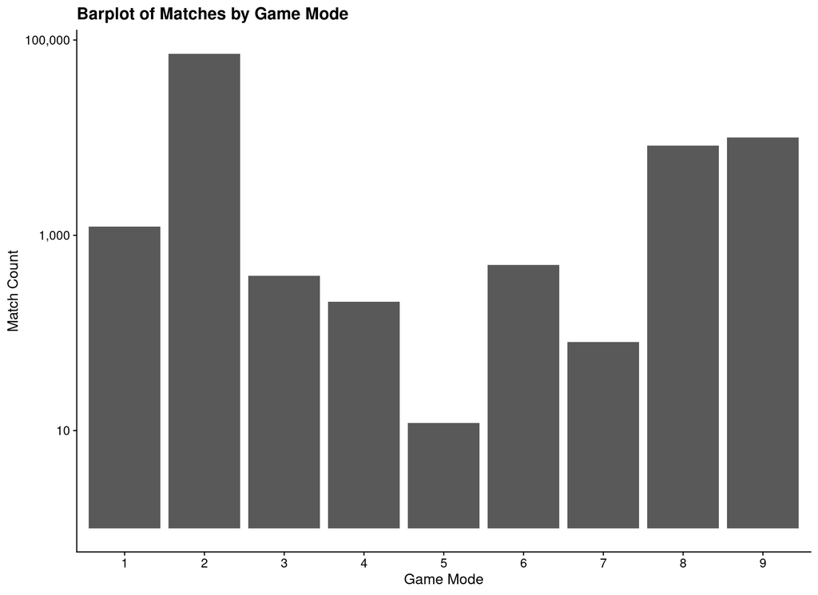

```r
plotdata_tbl <- matchdata_tbl %>%
  count(game_mode, name = "match_count")

ggplot(plotdata_tbl) +
  geom_col(aes(x = game_mode, y = match_count)) +
  labs(
    x = "Game Mode",
    y = "Match Count"
    ) +
  scale_y_log10(labels = label_comma()) +
  ggtitle("Barplot of Matches by Game Mode")
```

## 2.1 Plot Hero Appearances and Win-Rate

We want to look at how often the various heroes appear in the data set and what their individual win rate is.

```r
hero_winrate_tbl <- match_teamdata_tbl %>%
  count(hero_id, name, team_status, name = "n_appear") %>%
  group_by(name) %>%
  mutate(
    n_matches = sum(n_appear),
    prop      = n_appear / sum(n_appear)
    ) %>%
  ungroup()

hero_winrate_tbl %>% glimpse()
```

```
## Rows: 222
## Columns: 6
## $ hero_id     <chr> "1", "1", "10", "10", "100", "100", "101", "101", "102", "…
## $ name        <chr> "antimage", "antimage", "morphling", "morphling", "tusk", …
## $ team_status <chr> "LOSING TEAM", "WINNING TEAM", "LOSING TEAM", "WINNING TEA…
## $ n_appear    <int> 7981, 6992, 4889, 4918, 2169, 1590, 2433, 2101, 1849, 2230…
## $ n_matches   <int> 14973, 14973, 9807, 9807, 3759, 3759, 4534, 4534, 4079, 40…
## $ prop        <dbl> 0.5330261, 0.4669739, 0.4985215, 0.5014785, 0.5770152, 0.4…
```

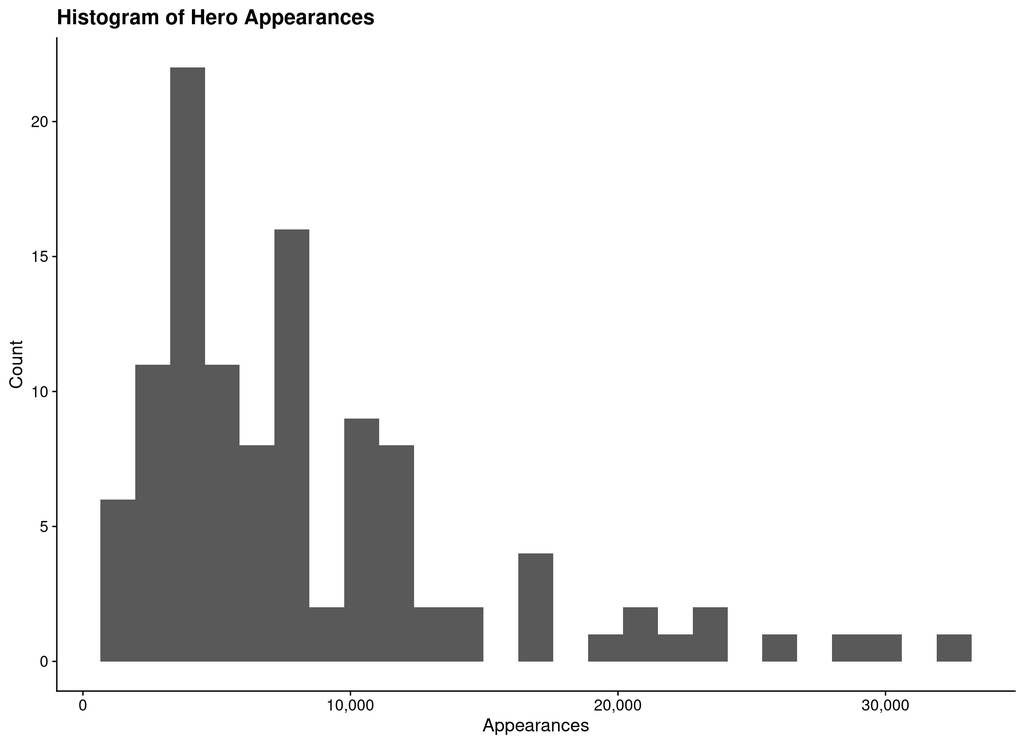

```r
plot_tbl <- hero_winrate_tbl %>%
  filter(team_status == "WINNING TEAM")

ggplot(plot_tbl) +
  geom_histogram(aes(x = n_matches), bins = 25) +
  scale_x_continuous(labels = label_comma()) +
  labs(
    x = "Appearances",
    y = "Count"
    ) +
  ggtitle("Histogram of Hero Appearances")
```

## 2.2 Plot Top Appearances by Region

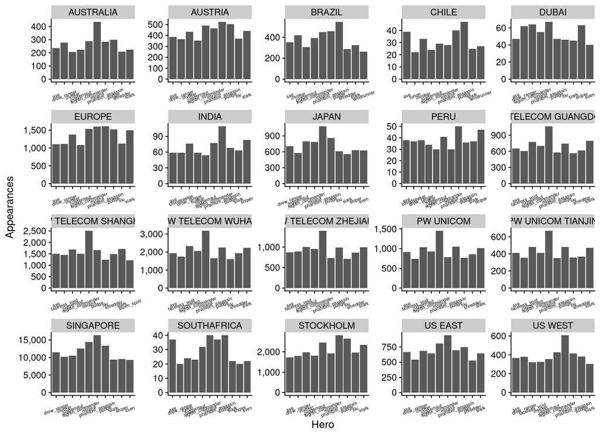

```r
region_appearance_tbl <- match_teamdata_tbl %>%
  count(region, name, name = "n_appear") %>%
  group_by(region) %>%
  slice_max(order_by = n_appear, n = 10) %>%
  ungroup()

ggplot(region_appearance_tbl) +
  geom_col(aes(x = name, y = n_appear)) +
  scale_y_continuous(labels = label_comma()) +
  labs(
    x = "Hero",
    y = "Appearances"
    ) +
  facet_wrap(vars(region), scales = "free") +
  theme(axis.text.x = element_text(angle = 20, vjust = 0.5, size = 6))
```

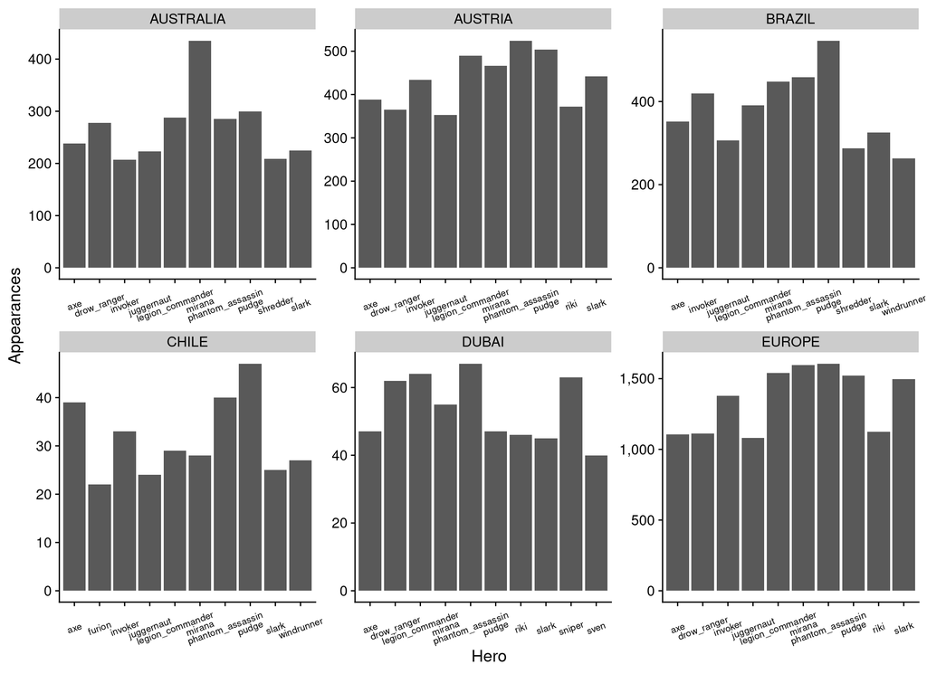

```r
nested_plot_tbl <- region_appearance_tbl %>%
  group_nest(region)

ggplot(nested_plot_tbl %>% slice(1:6) %>% unnest(data)) +
  geom_col(aes(x = name, y = n_appear)) +
  scale_y_continuous(labels = label_comma()) +
  labs(
    x = "Hero",
    y = "Appearances"
    ) +
  facet_wrap(vars(region), scales = "free") +
  theme(axis.text.x = element_text(angle = 20, vjust = 0.5, size = 8))
```

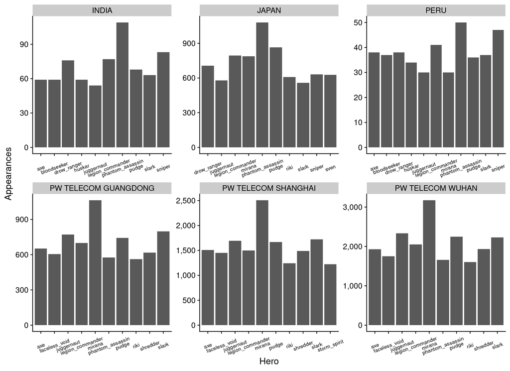

```r
ggplot(nested_plot_tbl %>% slice(7:12) %>% unnest(data)) +
  geom_col(aes(x = name, y = n_appear)) +
  scale_y_continuous(labels = label_comma()) +
  labs(
    x = "Hero",
    y = "Appearances"
    ) +
  facet_wrap(vars(region), scales = "free") +
  theme(axis.text.x = element_text(angle = 20, vjust = 0.5, size = 8))
```

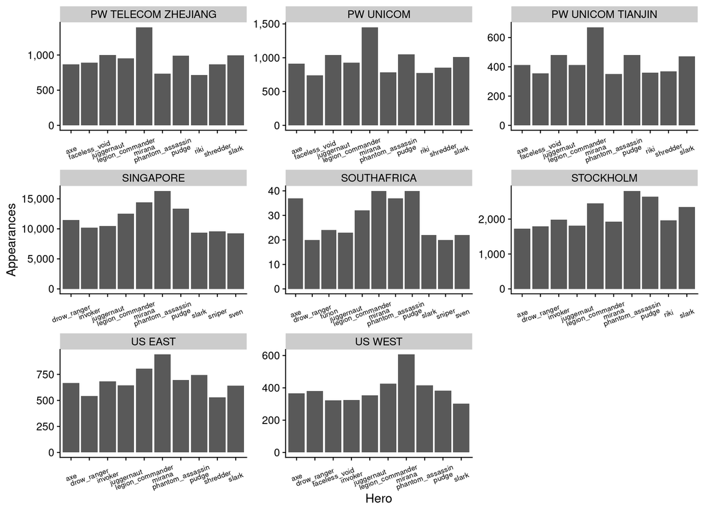

```r
ggplot(nested_plot_tbl %>% slice(13:20) %>% unnest(data)) +
  geom_col(aes(x = name, y = n_appear)) +
  scale_y_continuous(labels = label_comma()) +
  labs(
    x = "Hero",
    y = "Appearances"
    ) +
  facet_wrap(vars(region), scales = "free") +
  theme(axis.text.x = element_text(angle = 20, vjust = 0.5, size = 8))
```

# 3 Construct Mixed-Node Graph

We have a number of different was of thinking about how we might construct graphs from this data. The first and most obvious one is to convert both individual matches and the heroes as nodes on the graph.

```r
nodes_match_tbl <- match_teamdata_tbl %>%
  transmute(node_id = match_id, node_type = "Match", game_mode, game_type, region) %>%
  distinct()

nodes_hero_tbl <- match_teamdata_tbl %>%
  transmute(node_id = hero_id, node_type = "Hero", name, localized_name) %>%
  distinct()

mixed_nodes_tbl <- list(
    nodes_match_tbl,
    nodes_hero_tbl
    ) %>%
  bind_rows()

mixed_edges_tbl <- match_teamdata_tbl %>%
  select(from = match_id, to = hero_id, team_status)


mixednode_tblgraph <- tbl_graph(
  nodes    = mixed_nodes_tbl,
  edges    = mixed_edges_tbl,
  directed = FALSE,
  node_key = "node_id"
  )
```

# 4 Construct Hero-Node Graph

```r
calculate_pairwise_weights <- function(matchdata_tbl) {
  pairs_tbl <- expand_grid(
      one = matchdata_tbl %>% select(from = hero_id, st1 = team_status),
      two = matchdata_tbl %>% select(to   = hero_id, st2 = team_status)
      ) %>%
    unnest(c(one, two)) %>%
    mutate(
      team_win  = if_else(st1 == "WINNING TEAM" & st2 == "WINNING TEAM", 1, 0),
      winner    = if_else(st1 == "WINNING TEAM" & st2 == "LOSING TEAM",  1, 0),
      loser     = if_else(st1 == "LOSING TEAM"  & st2 == "WINNING TEAM", 1, 0),
      team_loss = if_else(st1 == "LOSING TEAM"  & st2 == "LOSING TEAM",  1, 0)
      )

  return(pairs_tbl)
}


hero_pairs_tbl <- match_teamdata_tbl %>%
  group_nest(match_id, .key = "match_data") %>%
  mutate(
    pairs_data = future_map(
      match_data, calculate_pairwise_weights,

      .progress = TRUE
      )
    )

hero_edges_tbl <- hero_pairs_tbl %>%
  select(pairs_data) %>%
  unnest(pairs_data) %>%
  group_by(from, to) %>%
  summarise(
    .groups = "drop",

    n_appear    = n(),
    across(
      c(team_win, team_loss, winner, loser),
      sum
      )
    ) %>%
  mutate(
    team_win_prop   = team_win  / n_appear,
    team_loss_prop  = team_loss / n_appear,
    winner_prop     = winner / n_appear,
    loser_prop      = loser  / n_appear,
    total_win_prop  = (team_win  + winner) / n_appear,
    total_loss_prop = (team_loss + loser) / n_appear,
    ) %>%
  arrange(from, to)

hero_edges_tbl %>% glimpse()
```

```
## Rows: 12,321
## Columns: 13
## $ from            <chr> "1", "1", "1", "1", "1", "1", "1", "1", "1", "1", "1",…
## $ to              <chr> "1", "10", "100", "101", "102", "103", "104", "105", "…
## $ n_appear        <int> 14973, 1321, 515, 725, 609, 806, 4142, 600, 1028, 351,…
## $ team_win        <dbl> 6992, 199, 100, 169, 139, 215, 793, 128, 180, 69, 79, …
## $ team_loss       <dbl> 7981, 221, 138, 177, 142, 189, 945, 148, 280, 102, 128…
## $ winner          <dbl> 0, 438, 154, 201, 149, 182, 1030, 154, 310, 98, 176, 4…
## $ loser           <dbl> 0, 463, 123, 178, 179, 220, 1374, 170, 258, 82, 211, 4…
## $ team_win_prop   <dbl> 0.4669739, 0.1506435, 0.1941748, 0.2331034, 0.2282430,…
## $ team_loss_prop  <dbl> 0.5330261, 0.1672975, 0.2679612, 0.2441379, 0.2331691,…
## $ winner_prop     <dbl> 0.0000000, 0.3315670, 0.2990291, 0.2772414, 0.2446634,…
## $ loser_prop      <dbl> 0.0000000, 0.3504921, 0.2388350, 0.2455172, 0.2939245,…
## $ total_win_prop  <dbl> 0.4669739, 0.4822104, 0.4932039, 0.5103448, 0.4729064,…
## $ total_loss_prop <dbl> 0.5330261, 0.5177896, 0.5067961, 0.4896552, 0.5270936,…
```

## 4.1 Construct Undirected Network

```r
hero_undirected_tblgraph <- tbl_graph(
    nodes    = hero_data_tbl,
    edges    = hero_edges_tbl %>% filter(as.numeric(from) < as.numeric(to)),
    directed = FALSE,
    node_key = "hero_id"
    ) %>%
  mutate(
    cntr_eigen_teamwin  = centrality_eigen(weights = team_win_prop),
    cntr_eigen_teamloss = centrality_eigen(weights = team_loss_prop),
    cntr_eigen_winner   = centrality_eigen(weights = winner_prop),
    cntr_eigen_loser    = centrality_eigen(weights = loser_prop)
    )

hero_undirected_tblgraph %>% print()
```

```
## # A tbl_graph: 112 nodes and 6105 edges
## #
## # An undirected simple graph with 2 components
## #
## # Node Data: 112 × 7 (active)
##   hero_id name  localized_name cntr_eigen_team… cntr_eigen_team…
##   <chr>   <chr> <chr>                     <dbl>            <dbl>
## 1 1       anti… Anti-Mage                 0.819            0.867
## 2 2       axe   Axe                       0.900            0.754
## 3 3       bane  Bane                      0.758            0.863
## 4 4       bloo… Bloodseeker               0.876            0.795
## 5 5       crys… Crystal Maiden            0.898            0.701
## 6 6       drow… Drow Ranger               0.934            0.753
## # … with 106 more rows, and 2 more variables: cntr_eigen_winner <dbl>,
## #   cntr_eigen_loser <dbl>
## #
## # Edge Data: 6,105 × 13
##    from    to n_appear team_win team_loss winner loser team_win_prop
##   <int> <int>    <int>    <dbl>     <dbl>  <dbl> <dbl>         <dbl>
## 1     1    11     1321      199       221    438   463         0.151
## 2     1    99      515      100       138    154   123         0.194
## 3     1   100      725      169       177    201   178         0.233
## # … with 6,102 more rows, and 5 more variables: team_loss_prop <dbl>,
## #   winner_prop <dbl>, loser_prop <dbl>, total_win_prop <dbl>,
## #   total_loss_prop <dbl>
```

```r
hero_undirected_tblgraph %>%
  convert(to_subgraph, hero_id %in% 1:5) %>%
  toVisNetworkData(idToLabel = FALSE) %>%
  visNetwork(
    nodes = .$nodes,
    edges = .$edges
    )
```

[interactive chart not shown]

## 4.2 Construct Directed Network

```r
hero_directed_tblgraph <- tbl_graph(
    nodes    = hero_data_tbl,
    edges    = hero_edges_tbl %>% filter(as.numeric(from) != as.numeric(to)),
    directed = TRUE,
    node_key = "hero_id"
    ) %>%
  mutate(
    cntr_eigen_teamwin  = centrality_eigen(weights = team_win_prop),
    cntr_eigen_teamloss = centrality_eigen(weights = team_loss_prop),
    cntr_eigen_winner   = centrality_eigen(weights = winner_prop),
    cntr_eigen_loser    = centrality_eigen(weights = loser_prop)
    )

hero_undirected_tblgraph %>% print()
```

```
## # A tbl_graph: 112 nodes and 6105 edges
## #
## # An undirected simple graph with 2 components
## #
## # Node Data: 112 × 7 (active)
##   hero_id name  localized_name cntr_eigen_team… cntr_eigen_team…
##   <chr>   <chr> <chr>                     <dbl>            <dbl>
## 1 1       anti… Anti-Mage                 0.819            0.867
## 2 2       axe   Axe                       0.900            0.754
## 3 3       bane  Bane                      0.758            0.863
## 4 4       bloo… Bloodseeker               0.876            0.795
## 5 5       crys… Crystal Maiden            0.898            0.701
## 6 6       drow… Drow Ranger               0.934            0.753
## # … with 106 more rows, and 2 more variables: cntr_eigen_winner <dbl>,
## #   cntr_eigen_loser <dbl>
## #
## # Edge Data: 6,105 × 13
##    from    to n_appear team_win team_loss winner loser team_win_prop
##   <int> <int>    <int>    <dbl>     <dbl>  <dbl> <dbl>         <dbl>
## 1     1    11     1321      199       221    438   463         0.151
## 2     1    99      515      100       138    154   123         0.194
## 3     1   100      725      169       177    201   178         0.233
## # … with 6,102 more rows, and 5 more variables: team_loss_prop <dbl>,
## #   winner_prop <dbl>, loser_prop <dbl>, total_win_prop <dbl>,
## #   total_loss_prop <dbl>
```

# 5 Investigate Association Rules

## 5.1 All Hero/Match Data

```r
match_teamdata_tbl %>%
  select(match_id, name, team_status) %>%
  write_csv("data/hero_matches.csv")

hero_arules <- read.transactions(
    file   = "data/hero_matches.csv",
    format = "single",
    sep    = ",",
    header = TRUE,
    cols   = c("match_id", "name")
    )
```

```r
hero_arules %>% ruleExplorer()
```

## 5.2 Winner Hero/Match Data

```r
match_teamdata_tbl %>%
  select(match_id, name, team_status) %>%
  filter(team_status == "WINNING TEAM") %>%
  write_csv("data/hero_matches_winner.csv")

hero_winner_arules <- read.transactions(
    file   = "data/hero_matches_winner.csv",
    format = "single",
    sep    = ",",
    header = TRUE,
    cols   = c("match_id", "name")
    )
```

```r
hero_winner_arules %>% ruleExplorer()
```